# Subject 7: The SARS-CoV-2 (Covid-19) epidemic

Author: Jana Koteich | January 2021

The goal is to produce plots similar to the one of the South China Morning Post ( SCMP ), on The Coronavirus Pandemic page, which shows for different countries the cumulative number (ie the total number since the beginning of the pandemic) of people with coronavirus 2019 disease .

1) First download the data and then show the results of the csv file:

```python
import pandas as pd
from matplotlib import pyplot as plt
import numpy as np
from matplotlib.ticker import NullFormatter
```

```python
time_series_covid19_confirmed_global = pd.read_csv("https://data.humdata.org/hxlproxy/api/data-preview.csv?url=https%3A%2F%2Fraw.githubusercontent.com%2FCSSEGISandData%2FCOVID-19%2Fmaster%2Fcsse_covid_19_data%2Fcsse_covid_19_time_series%2Ftime_series_covid19_confirmed_global.csv&filename=time_series_covid19_confirmed_global.csv")

time_series_covid19_confirmed_global.head()
```

|  | Province/State | Country/Region | Lat | Long | 1/22/20 | 1/23/20 | 1/24/20 | 1/25/20 | 1/26/20 | 1/27/20 | ... | 12/22/20 | 12/23/20 | 12/24/20 | 12/25/20 | 12/26/20 | 12/27/20 | 12/28/20 | 12/29/20 | 12/30/20 | 12/31/20 |
| --- | --- | --- | --- | --- | --- | --- | --- | --- | --- | --- | --- | --- | --- | --- | --- | --- | --- | --- | --- | --- | --- |
| 0 | NaN | Afghanistan | 33.93911 | 67.709953 | 0 | 0 | 0 | 0 | 0 | 0 | ... | 50190 | 50433 | 50655 | 50810 | 50886 | 51039 | 51280 | 51350 | 51405 | 51526 |
| 1 | NaN | Albania | 41.15330 | 20.168300 | 0 | 0 | 0 | 0 | 0 | 0 | ... | 53814 | 54317 | 54827 | 55380 | 55755 | 56254 | 56572 | 57146 | 57727 | 58316 |
| 2 | NaN | Algeria | 28.03390 | 1.659600 | 0 | 0 | 0 | 0 | 0 | 0 | ... | 96069 | 96549 | 97007 | 97441 | 97857 | 98249 | 98631 | 98988 | 99311 | 99610 |
| 3 | NaN | Andorra | 42.50630 | 1.521800 | 0 | 0 | 0 | 0 | 0 | 0 | ... | 7633 | 7669 | 7699 | 7756 | 7806 | 7821 | 7875 | 7919 | 7983 | 8049 |
| 4 | NaN | Angola | -11.20270 | 17.873900 | 0 | 0 | 0 | 0 | 0 | 0 | ... | 16802 | 16931 | 17029 | 17099 | 17149 | 17240 | 17296 | 17371 | 17433 | 17553 |

5 rows × 349 columns

Now let's plot the general graph of the csv file:

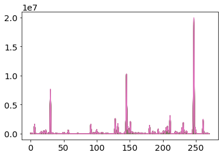

```python
time_series_covid19_confirmed_global.plot(legend=None)
```

You can see that we can barely analyse this graph or conclude anything from it, so let's update it.

As first attempt, we try to display the graph showing the evolution of the cumulative number of cases over time for one country, let's take Belgium as a try:

To select rows from Pandas DataFrame based on specified conditions (which is in our case choosing Belgium) we can use the following logic:

(Use the T attribute or the transpose() method to swap (= transpose) the rows and columns of pandas.DataFrame).

We drop columns Lat and Long because they are useless for our analysis.

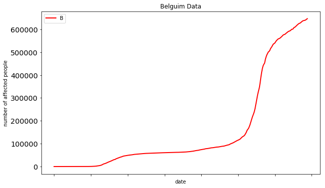

```python
Belgium=time_series_covid19_confirmed_global.loc[time_series_covid19_confirmed_global['Country/Region']=='Belgium'].T
Belgium = Belgium.drop(['Province/State','Country/Region','Lat','Long'], axis=0)
Belgium.plot(color='red', linewidth=2, marker='', figsize=(10, 6))
ax = plt.gca()  # Get the current Axes that ma.plot() references
ax.set_xlabel('date')
ax.set_ylabel('number of affected people')
ax.set_title('Belguim Data')
ax.grid(False)
#ax.legend(loc='upper center')
#ax.set_xlim(xmin=ma.index[0], xmax=ma.index[-1])

ax.legend('Belgium')
```

Then try to display the data of different countries that has no Province/State in a single graph, first we will add 'Hong Kong' to the column Country/Region.

```python
time_series_covid19_confirmed_global.loc[time_series_covid19_confirmed_global['Province/State']=='Hong Kong', 'Country/Region'] = 'Hong Kong'
x = time_series_covid19_confirmed_global.loc[time_series_covid19_confirmed_global['Country/Region']=='Hong Kong', : ]
x
```

|  | Province/State | Country/Region | Lat | Long | 1/22/20 | 1/23/20 | 1/24/20 | 1/25/20 | 1/26/20 | 1/27/20 | ... | 12/22/20 | 12/23/20 | 12/24/20 | 12/25/20 | 12/26/20 | 12/27/20 | 12/28/20 | 12/29/20 | 12/30/20 | 12/31/20 |
| --- | --- | --- | --- | --- | --- | --- | --- | --- | --- | --- | --- | --- | --- | --- | --- | --- | --- | --- | --- | --- | --- |
| 70 | Hong Kong | Hong Kong | 22.3 | 114.2 | 0 | 2 | 2 | 5 | 8 | 8 | ... | 8300 | 8353 | 8424 | 8481 | 8540 | 8610 | 8671 | 8724 | 8778 | 8846 |

1 rows × 349 columns

1) Put the desired countries in a list

2) Take the row related to the selected country and reverse it to column

3) Repeat same step and append the new columns to the DataFrame that is created

```python
list_Countries=['Belgium','Germany','Iran','Italy','Japan','Korea South','Portugal','Spain','US','Hong Kong']
df = pd.DataFrame(new)
for i in time_series_covid19_confirmed_global['Country/Region']:
    for j in list_Countries:
        if i==j:
            new=time_series_covid19_confirmed_global.loc[time_series_covid19_confirmed_global['Country/Region']==j].T
            new=new.drop(['Province/State','Country/Region','Lat','Long'], axis=0)
            df[j]=new
df.head()
#country = country.reset_index()
#country = country.rename(columns={'index': 'Date'})
```

|  | 247 | Belgium | Hong Kong | Germany | Iran | Italy | Japan | Portugal | Spain | US |
| --- | --- | --- | --- | --- | --- | --- | --- | --- | --- | --- |
| 1/22/20 | 1 | 0 | 0 | 0 | 0 | 0 | 2 | 0 | 0 | 1 |
| 1/23/20 | 1 | 0 | 2 | 0 | 0 | 0 | 2 | 0 | 0 | 1 |
| 1/24/20 | 2 | 0 | 2 | 0 | 0 | 0 | 2 | 0 | 0 | 2 |
| 1/25/20 | 2 | 0 | 5 | 0 | 0 | 0 | 2 | 0 | 0 | 2 |
| 1/26/20 | 5 | 0 | 8 | 0 | 0 | 0 | 4 | 0 | 0 | 5 |

Delete the column '247'

```python
del df[247]
```

```python
df.head()
```

|  | Belgium | Hong Kong | Germany | Iran | Italy | Japan | Portugal | Spain | US |
| --- | --- | --- | --- | --- | --- | --- | --- | --- | --- |
| 1/22/20 | 0 | 0 | 0 | 0 | 0 | 2 | 0 | 0 | 1 |
| 1/23/20 | 0 | 2 | 0 | 0 | 0 | 2 | 0 | 0 | 1 |
| 1/24/20 | 0 | 2 | 0 | 0 | 0 | 2 | 0 | 0 | 2 |
| 1/25/20 | 0 | 5 | 0 | 0 | 0 | 2 | 0 | 0 | 2 |
| 1/26/20 | 0 | 8 | 0 | 0 | 0 | 4 | 0 | 0 | 5 |

Collect all the dates from the initial dataFrame.

```python
dates = pd.to_datetime(time_series_covid19_confirmed_global.columns.values[4:])
dates
#plt.xticks(x, labels, rotation ='vertical')
```

```
DatetimeIndex(['2020-01-22', '2020-01-23', '2020-01-24', '2020-01-25',
               '2020-01-26', '2020-01-27', '2020-01-28', '2020-01-29',
               '2020-01-30', '2020-01-31',
               ...
               '2020-12-22', '2020-12-23', '2020-12-24', '2020-12-25',
               '2020-12-26', '2020-12-27', '2020-12-28', '2020-12-29',
               '2020-12-30', '2020-12-31'],
              dtype='datetime64[ns]', length=345, freq=None)
```

# Plot the graph:

We increase the size of the graph to visualize it better.

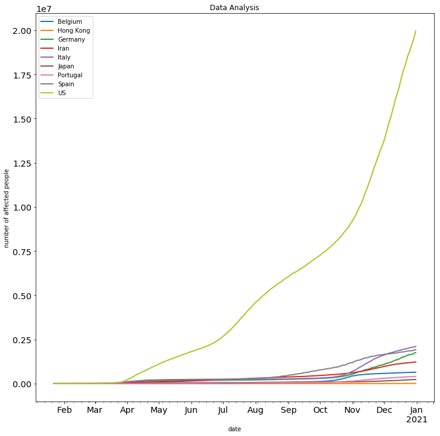

```python
df.plot(dates,linewidth=2, figsize=(12, 12))
ay = plt.gca()  # Get the current Axes that ma.plot() references
ay.set_xlabel('date')
ay.set_ylabel('number of affected people')
ay.set_title('Data Analysis')
ay.grid(False)
plt.rc('xtick', labelsize='x-large')
plt.rc('ytick', labelsize='x-large')
```

# Logarithmic and Linear scales

Next, make a graph with the date on the x-axis and the cumulative number of cases at this date on the y-axis.

Version 1: Linear scale

The graph is plotted with grids which make reading the graph easier.

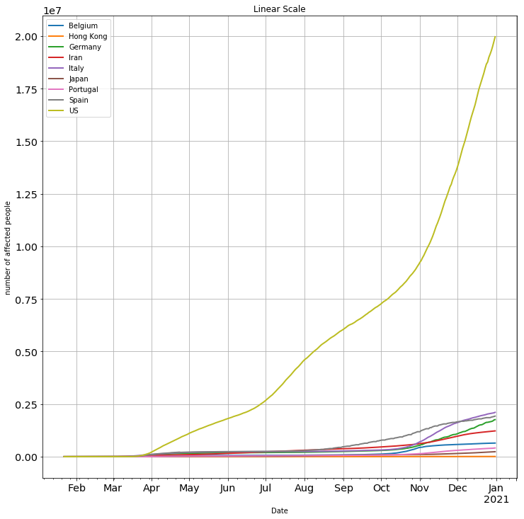

```python
df.plot(dates,linewidth=2, figsize=(12, 12))
ay = plt.gca()  # Get the current Axes that ma.plot() references
ay.set_xlabel('Date')
ay.set_ylabel('number of affected people')
ay.set_title('Linear Scale')
ay.grid(True)
plt.rc('xtick', labelsize='x-large')
plt.rc('ytick', labelsize='x-large')
plt.yscale('linear')
```

version 2: Logarithmic scale

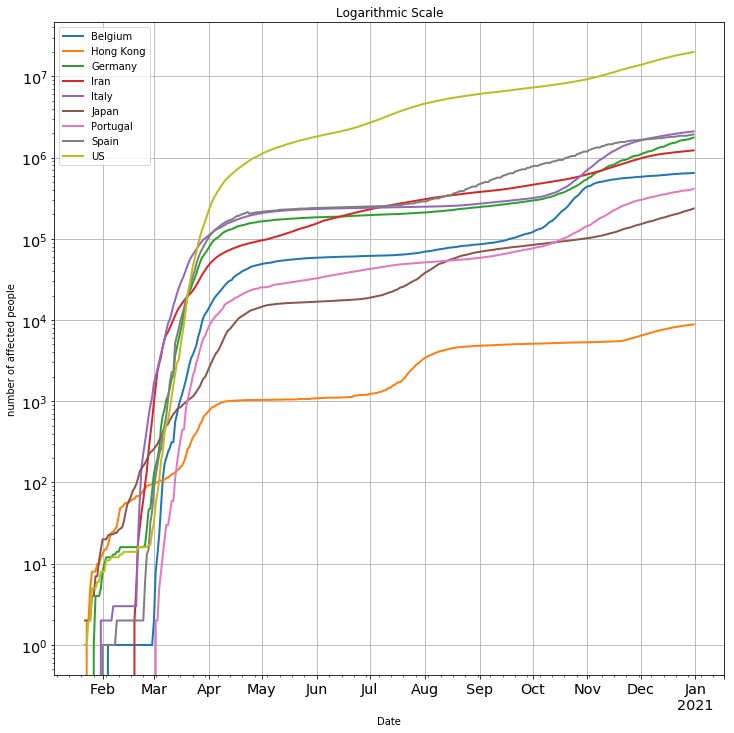

```python
df.plot(dates,linewidth=2, figsize=(12, 12))
ay = plt.gca()  # Get the current Axes that ma.plot() references
ay.set_xlabel('Date')
ay.set_ylabel('number of affected people')
ay.set_title('Logarithmic Scale')
ay.grid(True)
plt.rc('xtick', labelsize='x-large')
plt.rc('ytick', labelsize='x-large')
plt.yscale('log')
```